# 07 Graficas

2024-02-08

## Análisis de datos I (MAT1409)

## 3 Representación Gráfica y Tabular

## Tema. 3.1.1 Histograma: Características.

- Un histograma es una representación gráfica de datos donde los datos o clases se agrupan en frecuencias o porcentajes (frecuencia relativa) y se representan en una barra vertical.
- El eje horizontal muestran los datos/clases de los datos y el eje vertical la frecuencia.
- En un histograma, no hay espacios entre las barras, a diferencia de un gráfico de barras.
- La altura de las barras es proporcional a las frecuencias correspondientes.
- Un histograma puede mostrar la forma de los datos, el centro y la dispersión de los datos.

## Tema. 3.1.1 Histograma: Usos.

- Ayuda a visualizar medidas de tendencia central y la distribución de los datos.
- Verificar si un proceso cambia de un período a otro.
- Identificar valores extremos potenciales.
- Como ranking (top sells, top universities, …)

## Tema. 3.1.1 Histograma con Frecuencias.

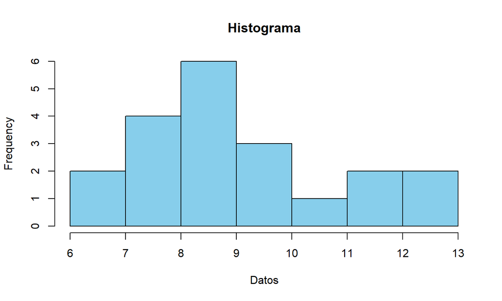

## Tema. 3.1.1 Histograma con Frecuencias Relativas.

Tabla de Frecuencia

| 6 | 7 | 8 | 9 | 10 | 11 | 12 | 13 |
| --- | --- | --- | --- | --- | --- | --- | --- |
| 1 | 1 | 4 | 6 | 3 | 1 | 2 | 2 |

Frecuencia Relativa: \[f_{\text{relativa}} = \frac{f_{\text{absoluta}}}{N}\] Ejemplo para \(9\):

```r
6/20
```

```
## [1] 0.3
```

## Tema. 3.1.1 Histograma con Frecuencias Relativas.

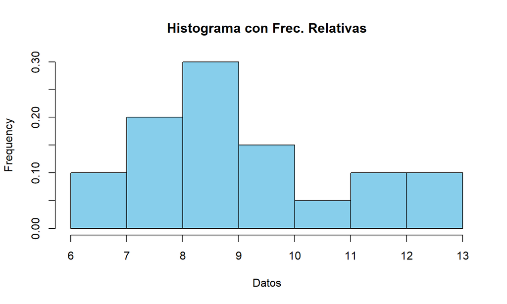

## Tema. 3.1.1 Histograma con Clases (1/1).

- Representar variables continuas.
- Cuando hay grupos dentro de la muestra.
- Cuando el rango de los datos es grande.
- Cuando es conveniente dividir la muestra.

## Tema. 3.1.1 Histograma con Clases (1/2).

Reglas para determinar el número de clases:

- Regla de Sturges: \[k_{\text{Sturges}} = 1 + 3.322 \log_{10}(n)\]
- Regla de Rice: \[k_{\text{Rice}} = 2n^{1/3}\]
- Regla de la Raiz Cuadrada: \[k_{\text{Raíz Cuadrada}} = \sqrt{n}\]

*Redondear hacia arriba*

## Tema. 3.1.1 Histograma con Clases (1/3).

Determinar el rango de la clase:

\[\Delta{c} = \frac{\Delta}{k}\]

El rango: \[ \Delta = \max(X) - \min(X) \]

## Tema. 3.1.1 Histograma con Clases (1/4).

Ejemplo con datos: \[6.98, 7.96, 8.76, 9.03, \\ 9.47, 9.54, 9.77, 9.77, 10, \\ 10.25,10.79, 11.04, 11.96, \\ 12.64, 14.44\]

Usamos la regla de Sturges: \[k_{\text{Sturges}} = 1 + 3.322 \log_{10}(15)=5\]

```r
1+3.322*log10(15)
```

```
## [1] 4.906975
```

## Tema. 3.1.1 Histograma con Clases (1/5).

Calculamos el rango:

```r
14.44-6.98
```

```
## [1] 7.46
```

[output not shown]

## Tema. 3.1.1 Histograma con Clases (1/6).

Determinar los intervalos: \[1: [6.98, 6.98+1.5)= [6.98, 8.48)\]

\[2: [8.48, 9.98) \]

## Tema. 3.1.1 Histograma con Clases (1/7).

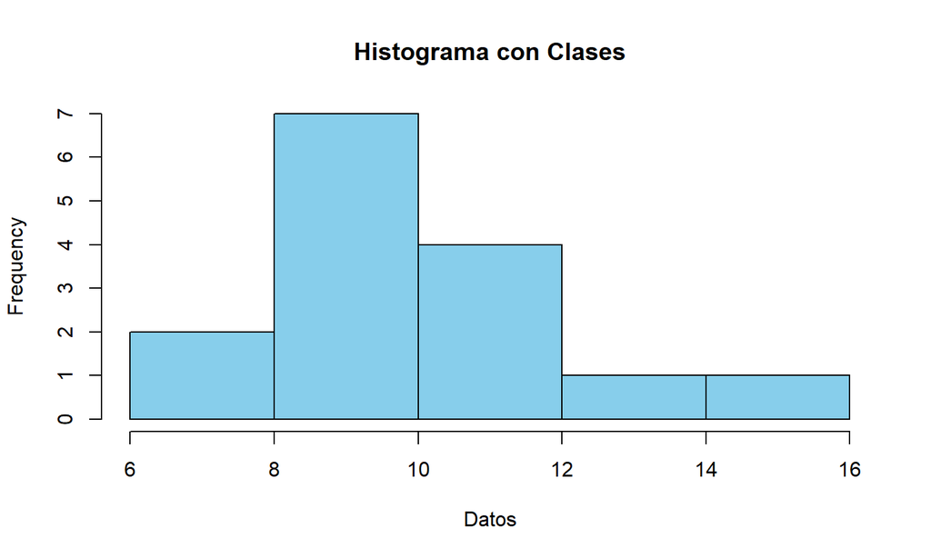

## Tema. 3.1.1 Histograma con Ejercicio.

Elige una regla para el cómputo de las clases y crea un histograma:

\[6.98, 7.96, 8.76, 9.03, \\ 9.47, 9.54, 9.77, 9.77, 10, \\ 10.25,10.79, 11.04, 11.96, \\ 12.64, 14.44\]

## Revisión

## Revisión

```
## Versión: 08/02/2024
```

## Bibliografía

## Bibliografía

- Dodge, Y. (2008). The concise encyclopedia of statistics. Springer Science & Business Media.
- Business Mathematics.(2023).SBPD https://www.google.com.mx/books/edition/Business_Mathematics/oRLFEAAAQBAJ
- Smith, G. (2015). *Essential statistics, regression, and econometrics.*
- Boston University. (s/f). Summarizing Data. Recuperado de https://sphweb.bumc.bu.edu/otlt/mph-modules/bs/bs704_summarizingdata/bs704_summarizingdata7.html